# Hierarchical Model

Alice Jiang

11/17/2020

```r
library(tidyverse)
#library(nlme)
library(lme4)
```

```r
library(ggplot2)
library(dplyr)
library(sjPlot) #for plotting lmer and glmer mods
library(groupdata2)
library(hydroGOF) # rmse()
mydata <- read_csv("covid.csv")
mydata <- mydata[is.finite(mydata$covid_death_rate_log),]
mydata$name <- as.factor(mydata$name)
mydata$region <- as.factor(mydata$region)
mydata$state <- as.factor(mydata$state)
mydata$govParty <- as.factor(mydata$govParty)
mydata$metro_area <- as.factor(mydata$metro_area)
mydata$main_econ <- as.factor(mydata$main_econ)
mydata$GQ_ESTIMATES_2019 <- log(mydata$GQ_ESTIMATES_2019)
mydata <- mydata %>%
  filter(GQ_ESTIMATES_2019 != '-Inf') %>%
  mutate(density = total_population/area_sqmi)
mydata <- mydata[,-c(1:3,29:31)]
```

```r
summary(mydata)
```

```
##      state        popChange        GQ_ESTIMATES_2019   birthRate
##  TX     : 232   Min.   :-34799.0   Min.   : 0.000    Min.   : 0.80
##  GA     : 151   1st Qu.:  -104.0   1st Qu.: 5.428    1st Qu.: 9.70
##  VA     : 123   Median :     9.0   Median : 6.592    Median :10.95
##  MO     : 110   Mean   :   569.4   Mean   : 6.631    Mean   :11.08
##  KY     : 104   3rd Qu.:   287.0   3rd Qu.: 7.847    3rd Qu.:12.20
##  NC     : 100   Max.   : 83011.0   Max.   :12.097    Max.   :28.20
##  (Other):2012
##    deathRate      increaseRate      intMigrationRate  domMigrationRate
##  Min.   : 2.10   Min.   :-13.5000   Min.   :-1.7000   Min.   :-165.30000
##  1st Qu.: 8.90   1st Qu.: -1.9000   1st Qu.: 0.0000   1st Qu.:  -5.70000
##  Median :10.60   Median :  0.3000   Median : 0.2000   Median :  -0.70000
##  Mean   :10.51   Mean   :  0.5619   Mean   : 0.6285   Mean   :  -0.07486
##  3rd Qu.:12.20   3rd Qu.:  2.7000   3rd Qu.: 0.8000   3rd Qu.:   5.40000
##  Max.   :22.10   Max.   : 24.4000   Max.   :26.0000   Max.   :  86.10000
##
##  netMigrationRate       proTrump             region           govParty
##  Min.   :-165.4000   Min.   :0.04087   Midwest  : 946   Democrat  :1208
##  1st Qu.:  -5.1000   1st Qu.:0.53954   Northeast: 189   Republican:1624
##  Median :   0.0000   Median :0.65594   South    :1398
##  Mean   :   0.5535   Mean   :0.62632   West     : 299
##  3rd Qu.:   5.9000   3rd Qu.:0.74039
##  Max.   :  85.7000   Max.   :0.90500
##
##      metro_area            main_econ         lon               lat
##  adjacent : 955   farming       : 332   Min.   :-124.16   Min.   :25.51
##  metro    :1131   government    : 371   1st Qu.: -97.10   1st Qu.:34.46
##  non-metro: 746   manufacturing : 479   Median : -89.50   Median :38.09
##                   mining        : 190   Mean   : -91.07   Mean   :38.11
##                   nonspecialized:1172   3rd Qu.: -83.17   3rd Qu.:41.64
##                   recreation    : 288   Max.   : -68.35   Max.   :48.83
##
##  per_capita_income percent_below_poverty percent_minorities
##  Min.   : 9688     Min.   : 2.7          Min.   : 0.60
##  1st Qu.:20920     1st Qu.:12.0          1st Qu.: 7.10
##  Median :24150     Median :15.9          Median :16.20
##  Mean   :24887     Mean   :16.6          Mean   :23.26
##  3rd Qu.:27820     3rd Qu.:20.1          3rd Qu.:35.00
##  Max.   :66104     Max.   :48.7          Max.   :99.20
##
```

[output cut: 9 more lines]

```
##  Min.   :    2.051   Min.   : 5.909   Min.   : 8.121
##  1st Qu.:  430.636   1st Qu.:15.090   1st Qu.:14.504
##  Median :  604.184   Median :17.143   Median :17.402
##  Mean   :  935.320   Mean   :17.574   Mean   :18.084
##  3rd Qu.:  900.820   3rd Qu.:19.858   3rd Qu.:21.069
##  Max.   :20057.273   Max.   :41.491   Max.   :40.991
##
##  covid_death_rate_log    density
##  Min.   :-9.911       Min.   :    0.485
##  1st Qu.:-4.611       1st Qu.:   21.889
##  Median :-3.993       Median :   50.767
##  Mean   :-4.124       Mean   :  232.783
##  3rd Qu.:-3.457       3rd Qu.:  133.011
##  Max.   :-1.384       Max.   :18131.890
##
```

```r
#summary(mydata$name)
```

$name$: county demographic factors: $total\_population$, $percent\_fair\_or\_poor\_health$, $per\_capita\_income$ social factors: $percent\_uninsured$, $percent\_minorities$, $percent\_below\_poverty$, $percentile\_rank\_social\_vulnerability$ geographical factors: $region$ and $state$ economic factors: $main\_econ$ and $metro\_area$ political factors: $pro\_Trump$ and $govParty$

$GQ\_ESTIMATES\_2019$: the total number of county residents living in group quarters in 2019 (e.g. nursing homes, residential treatment centers, student housing, religious convents/monasteries, correctional facilities, and hospitals)

[output not shown]

# EDA

[output not shown]

[output not shown]

# Linear Mixed Model

[output not shown]

```r
#creating a training set
smp_size <- floor(0.8 * nrow(mydata))

set.seed(1)
train_ind <- sample(seq_len(nrow(mydata)), size = smp_size)

train <- mydata[train_ind, ]
test <- mydata[-train_ind, ]
```

```r
model1 <- lmer(covid_death_rate_log ~ . - region - state + (1|region), data = train)
```

```r
#summary(model1)
sjPlot::tab_model(model1, show.re.var= TRUE,
                  #pred.labels =c("(Intercept)", "per capita income:percent minorities"...),
                  dv.labels= "Effect of Socio-economic Factors on County COVID Death Rates")
```

|  | Effect of Socio-economic Factors on County COVID Death Rates |  |  |
| --- | --- | --- | --- |
| Predictors | Estimates | CI | p |
| (Intercept) | -2.84 | -4.15 – -1.52 | **<0.001** |
| popChange | -0.00 | -0.00 – 0.00 | 0.494 |
| GQ_ESTIMATES_2019 | -0.01 | -0.05 – 0.02 | 0.538 |
| birthRate | -0.19 | -0.96 – 0.59 | 0.638 |
| deathRate | 0.19 | -0.58 – 0.97 | 0.622 |
| increaseRate | 0.15 | -0.62 – 0.93 | 0.695 |
| intMigrationRate | -0.39 | -1.21 – 0.43 | 0.349 |
| domMigrationRate | -0.36 | -1.18 – 0.46 | 0.389 |
| netMigrationRate | 0.36 | -0.46 – 1.18 | 0.391 |
| proTrump | 0.86 | 0.33 – 1.40 | **0.001** |
| govParty [Republican] | 0.05 | -0.05 – 0.15 | 0.318 |
| metro_area [metro] | 0.07 | -0.04 – 0.17 | 0.216 |
| metro_area [non-metro] | -0.22 | -0.33 – -0.12 | **<0.001** |
| main_econ [government] | 0.03 | -0.16 – 0.21 | 0.770 |
| main_econ [manufacturing] | 0.19 | 0.02 – 0.35 | **0.026** |
| main_econ [mining] | 0.17 | -0.02 – 0.37 | 0.078 |
| main_econ [nonspecialized] | 0.26 | 0.11 – 0.41 | **0.001** |
| main_econ [recreation] | 0.17 | -0.01 – 0.36 | 0.069 |
| lon | 0.02 | 0.02 – 0.03 | **<0.001** |
| lat | -0.02 | -0.04 – -0.01 | **0.006** |
| per_capita_income | 0.00 | 0.00 – 0.00 | **<0.001** |
| percent_below_poverty | 0.02 | 0.00 – 0.03 | **0.014** |
| percent_minorities | 0.01 | 0.01 – 0.02 | **<0.001** |
| percentile_rank_social_vulnerability | 0.21 | -0.13 – 0.54 | 0.233 |
| percent_uninsured | -0.01 | -0.03 – 0.00 | 0.054 |
| total_population | 0.00 | -0.00 – 0.00 | 0.409 |
| area_sqmi | 0.00 | -0.00 – 0.00 | 0.120 |
| percent_smokers | -0.05 | -0.07 – -0.02 | **<0.001** |
| percent_fair_or_poor_health | 0.03 | 0.00 – 0.05 | **0.032** |
| density | 0.00 | -0.00 – 0.00 | 0.375 |
| Random Effects |  |  |  |
| σ<sup>2</sup> | 0.87 |  |  |
| τ<sub>00</sub> <sub>region</sub> | 0.06 |  |  |
| ICC | 0.07 |  |  |
| N <sub>region</sub> | 4 |  |  |
| Observations | 2265 |  |  |
| Marginal R<sup>2</sup> / Conditional R<sup>2</sup> | 0.199 / 0.252 |  |  |

proTrump, metro_area(non-metro), main_econ(manufacturing, nonspecialized), lon, lat, per capita income, percent_below_poverty, percent_minorities, percent_smokers, percent_fair_or_poor_health

```r
model2 <- lmer(covid_death_rate_log ~ GQ_ESTIMATES_2019 + birthRate + deathRate + domMigrationRate + proTrump + lon + lat + per_capita_income + percent_below_poverty + percent_minorities + percentile_rank_social_vulnerability + percent_uninsured + percent_smokers + metro_area + main_econ + (1|region), data = train)
```

```r
sjPlot::tab_model(model2, show.re.var= TRUE,
                  #pred.labels =c("(Intercept)", "per capita income:percent minorities"...),
                  dv.labels= "Effect of Socio-economic Factors on County COVID Death Rates")
```

|  | Effect of Socio-economic Factors on County COVID Death Rates |  |  |
| --- | --- | --- | --- |
| Predictors | Estimates | CI | p |
| (Intercept) | -2.72 | -3.99 – -1.44 | **<0.001** |
| GQ_ESTIMATES_2019 | -0.01 | -0.05 – 0.02 | 0.381 |
| birthRate | -0.03 | -0.05 – -0.01 | **0.007** |
| deathRate | 0.04 | 0.02 – 0.07 | **<0.001** |
| domMigrationRate | -0.00 | -0.01 – 0.00 | 0.483 |
| proTrump | 0.89 | 0.36 – 1.42 | **0.001** |
| lon | 0.02 | 0.01 – 0.03 | **<0.001** |
| lat | -0.03 | -0.05 – -0.01 | **<0.001** |
| per_capita_income | 0.00 | 0.00 – 0.00 | **<0.001** |
| percent_below_poverty | 0.02 | 0.01 – 0.03 | **0.005** |
| percent_minorities | 0.01 | 0.01 – 0.02 | **<0.001** |
| percentile_rank_social_vulnerability | 0.24 | -0.09 – 0.57 | 0.158 |
| percent_uninsured | -0.01 | -0.03 – -0.00 | **0.022** |
| percent_smokers | -0.03 | -0.05 – -0.01 | **0.004** |
| metro_area [metro] | 0.07 | -0.04 – 0.17 | 0.212 |
| metro_area [non-metro] | -0.22 | -0.33 – -0.12 | **<0.001** |
| main_econ [government] | 0.02 | -0.16 – 0.21 | 0.824 |
| main_econ [manufacturing] | 0.19 | 0.03 – 0.36 | **0.023** |
| main_econ [mining] | 0.19 | -0.01 – 0.38 | 0.057 |
| main_econ [nonspecialized] | 0.27 | 0.12 – 0.42 | **0.001** |
| main_econ [recreation] | 0.18 | -0.01 – 0.37 | 0.059 |
| Random Effects |  |  |  |
| σ<sup>2</sup> | 0.87 |  |  |
| τ<sub>00</sub> <sub>region</sub> | 0.07 |  |  |
| ICC | 0.07 |  |  |
| N <sub>region</sub> | 4 |  |  |
| Observations | 2265 |  |  |
| Marginal R<sup>2</sup> / Conditional R<sup>2</sup> | 0.188 / 0.247 |  |  |

birthRate, deathRate, proTrump, lon, lat, per capita income, percent_below_poverty, percent_minorities, percent_uninsured, percent_smokers, metro_area(non-metro), main_econ(manufacturing, nonspecialized)

[output not shown]

[output not shown]

[output not shown]

[output not shown]

[output not shown]

[output not shown]

[output not shown]

[output not shown]

[output not shown]

[output not shown]

[output not shown]

```r
model14 <- lmer(covid_death_rate_log ~ GQ_ESTIMATES_2019 + birthRate + deathRate + proTrump + lon + lat + per_capita_income + percent_below_poverty + percent_minorities + percentile_rank_social_vulnerability + percent_uninsured + percent_smokers + metro_area + main_econ + percent_fair_or_poor_health + (1|region) +   percentile_rank_social_vulnerability*percent_fair_or_poor_health, data = train)
```

```r
sjPlot::tab_model(model14, show.re.var= TRUE,
                  #pred.labels =c("(Intercept)", "per capita income:percent minorities"...),
                  dv.labels= "Effect of Socio-economic Factors on County COVID Death Rates")
```

|  | Effect of Socio-economic Factors on County COVID Death Rates |  |  |
| --- | --- | --- | --- |
| Predictors | Estimates | CI | p |
| (Intercept) | -3.46 | -4.82 – -2.10 | **<0.001** |
| GQ_ESTIMATES_2019 | -0.01 | -0.05 – 0.02 | 0.442 |
| birthRate | -0.03 | -0.05 – -0.01 | **0.010** |
| deathRate | 0.04 | 0.02 – 0.06 | **<0.001** |
| proTrump | 0.83 | 0.30 – 1.36 | **0.002** |
| lon | 0.02 | 0.01 – 0.03 | **<0.001** |
| lat | -0.02 | -0.04 – -0.01 | **0.004** |
| per_capita_income | 0.00 | 0.00 – 0.00 | **<0.001** |
| percent_below_poverty | 0.02 | 0.01 – 0.03 | **0.007** |
| percent_minorities | 0.01 | 0.01 – 0.02 | **<0.001** |
| percentile_rank_social_vulnerability | 0.81 | 0.17 – 1.45 | **0.013** |
| percent_uninsured | -0.01 | -0.03 – -0.00 | **0.021** |
| percent_smokers | -0.05 | -0.07 – -0.02 | **<0.001** |
| metro_area [metro] | 0.05 | -0.05 – 0.16 | 0.321 |
| metro_area [non-metro] | -0.22 | -0.32 – -0.11 | **<0.001** |
| main_econ [government] | 0.02 | -0.17 – 0.20 | 0.869 |
| main_econ [manufacturing] | 0.18 | 0.02 – 0.34 | **0.032** |
| main_econ [mining] | 0.16 | -0.03 – 0.36 | 0.095 |
| main_econ [nonspecialized] | 0.26 | 0.11 – 0.41 | **0.001** |
| main_econ [recreation] | 0.17 | -0.01 – 0.35 | 0.072 |
| percent_fair_or_poor_health | 0.05 | 0.02 – 0.09 | **0.002** |
| percentile_rank_social_vulnerability * percent_fair_or_poor_health | -0.04 | -0.08 – -0.00 | **0.029** |
| Random Effects |  |  |  |
| σ<sup>2</sup> | 0.87 |  |  |
| τ<sub>00</sub> <sub>region</sub> | 0.07 |  |  |
| ICC | 0.07 |  |  |
| N <sub>region</sub> | 4 |  |  |
| Observations | 2265 |  |  |
| Marginal R<sup>2</sup> / Conditional R<sup>2</sup> | 0.197 / 0.254 |  |  |

```r
final.model <- lmer(covid_death_rate_log ~ GQ_ESTIMATES_2019 + birthRate + deathRate + proTrump + lon + lat + per_capita_income + percent_below_poverty + percent_minorities + percentile_rank_social_vulnerability + percent_uninsured + percent_smokers + metro_area + main_econ + percent_fair_or_poor_health + (1|region) + percentile_rank_social_vulnerability*percent_fair_or_poor_health, data = train)
anova(final.model, model14, model1, model2)
```

```
## refitting model(s) with ML (instead of REML)
```

|  | Df | AIC | BIC | logLik | deviance | Chisq | Chi Df | Pr(>Chisq) |
| --- | --- | --- | --- | --- | --- | --- | --- | --- |
| model2 | 23 | 6153.604 | 6285.287 | -3053.802 | 6107.604 | NA | NA | NA |
| final.model | 24 | 6146.751 | 6284.158 | -3049.375 | 6098.751 | 8.853619 | 1 | 0.002925084 |
| model14 | 24 | 6146.751 | 6284.158 | -3049.375 | 6098.751 | 0.000000 | 0 | 1.000000000 |
| model1 | 32 | 6157.068 | 6340.279 | -3046.534 | 6093.068 | 5.682297 | 8 | 0.682770028 |

```r
summary(final.model)
```

```
## Linear mixed model fit by REML ['lmerMod']
## Formula: covid_death_rate_log ~ GQ_ESTIMATES_2019 + birthRate + deathRate +
##     proTrump + lon + lat + per_capita_income + percent_below_poverty +
##     percent_minorities + percentile_rank_social_vulnerability +
##     percent_uninsured + percent_smokers + metro_area + main_econ +
##     percent_fair_or_poor_health + (1 | region) + percentile_rank_social_vulnerability *
##     percent_fair_or_poor_health
##    Data: train
##
## REML criterion at convergence: 6242.2
##
## Scaled residuals:
##     Min      1Q  Median      3Q     Max
## -5.0154 -0.4812  0.0725  0.5905  3.7943
##
## Random effects:
##  Groups   Name        Variance Std.Dev.
##  region   (Intercept) 0.06652  0.2579
##  Residual             0.86794  0.9316
## Number of obs: 2265, groups:  region, 4
##
## Fixed effects:
##                                                                    Estimate
## (Intercept)                                                      -3.464e+00
## GQ_ESTIMATES_2019                                                -1.332e-02
## birthRate                                                        -2.846e-02
## deathRate                                                         4.418e-02
## proTrump                                                          8.268e-01
## lon                                                               1.993e-02
## lat                                                              -2.393e-02
## per_capita_income                                                 3.463e-05
## percent_below_poverty                                             1.961e-02
## percent_minorities                                                1.318e-02
## percentile_rank_social_vulnerability                              8.133e-01
## percent_uninsured                                                -1.488e-02
## percent_smokers                                                  -4.549e-02
## metro_areametro                                                   5.317e-02
## metro_areanon-metro                                              -2.197e-01
## main_econgovernment                                               1.548e-02
## main_econmanufacturing                                            1.783e-01
```

[output cut: 36 more lines]

```
## per_capita_income                                                  5.400
## percent_below_poverty                                              2.703
## percent_minorities                                                 5.146
## percentile_rank_social_vulnerability                               2.492
## percent_uninsured                                                 -2.312
## percent_smokers                                                   -3.740
## metro_areametro                                                    0.993
## metro_areanon-metro                                               -4.092
## main_econgovernment                                                0.165
## main_econmanufacturing                                             2.143
## main_econmining                                                    1.667
## main_econnonspecialized                                            3.403
## main_econrecreation                                                1.801
## percent_fair_or_poor_health                                        3.042
## percentile_rank_social_vulnerability:percent_fair_or_poor_health  -2.186
```

```
##
## Correlation matrix not shown by default, as p = 22 > 12.
## Use print(x, correlation=TRUE)  or
##     vcov(x)        if you need it
```

```
## fit warnings:
## Some predictor variables are on very different scales: consider rescaling
```

covid_death_rate_log ~ GQ_ESTIMATES_2019 + birthRate + deathRate +  
proTrump + lon + lat + per_capita_income + percent_below_poverty +  
percent_minorities + percentile_rank_social_vulnerability +  
percent_uninsured + percent_smokers + metro_area + main_econ +  
percent_fair_or_poor_health + (1 | region) +  
percentile_rank_social_vulnerability * percent_fair_or_poor_health

# Plots

```r
sjPlot::tab_model(final.model, show.re.var= TRUE,
                  #pred.labels =c("(Intercept)", "per capita income:percent minorities"...),
                  dv.labels= "Effect of Socio-economic Factors on County COVID Death Rates")
```

|  | Effect of Socio-economic Factors on County COVID Death Rates |  |  |
| --- | --- | --- | --- |
| Predictors | Estimates | CI | p |
| (Intercept) | -3.46 | -4.82 – -2.10 | **<0.001** |
| GQ_ESTIMATES_2019 | -0.01 | -0.05 – 0.02 | 0.442 |
| birthRate | -0.03 | -0.05 – -0.01 | **0.010** |
| deathRate | 0.04 | 0.02 – 0.06 | **<0.001** |
| proTrump | 0.83 | 0.30 – 1.36 | **0.002** |
| lon | 0.02 | 0.01 – 0.03 | **<0.001** |
| lat | -0.02 | -0.04 – -0.01 | **0.004** |
| per_capita_income | 0.00 | 0.00 – 0.00 | **<0.001** |
| percent_below_poverty | 0.02 | 0.01 – 0.03 | **0.007** |
| percent_minorities | 0.01 | 0.01 – 0.02 | **<0.001** |
| percentile_rank_social_vulnerability | 0.81 | 0.17 – 1.45 | **0.013** |
| percent_uninsured | -0.01 | -0.03 – -0.00 | **0.021** |
| percent_smokers | -0.05 | -0.07 – -0.02 | **<0.001** |
| metro_area [metro] | 0.05 | -0.05 – 0.16 | 0.321 |
| metro_area [non-metro] | -0.22 | -0.32 – -0.11 | **<0.001** |
| main_econ [government] | 0.02 | -0.17 – 0.20 | 0.869 |
| main_econ [manufacturing] | 0.18 | 0.02 – 0.34 | **0.032** |
| main_econ [mining] | 0.16 | -0.03 – 0.36 | 0.095 |
| main_econ [nonspecialized] | 0.26 | 0.11 – 0.41 | **0.001** |
| main_econ [recreation] | 0.17 | -0.01 – 0.35 | 0.072 |
| percent_fair_or_poor_health | 0.05 | 0.02 – 0.09 | **0.002** |
| percentile_rank_social_vulnerability * percent_fair_or_poor_health | -0.04 | -0.08 – -0.00 | **0.029** |
| Random Effects |  |  |  |
| σ<sup>2</sup> | 0.87 |  |  |
| τ<sub>00</sub> <sub>region</sub> | 0.07 |  |  |
| ICC | 0.07 |  |  |
| N <sub>region</sub> | 4 |  |  |
| Observations | 2265 |  |  |
| Marginal R<sup>2</sup> / Conditional R<sup>2</sup> | 0.197 / 0.254 |  |  |

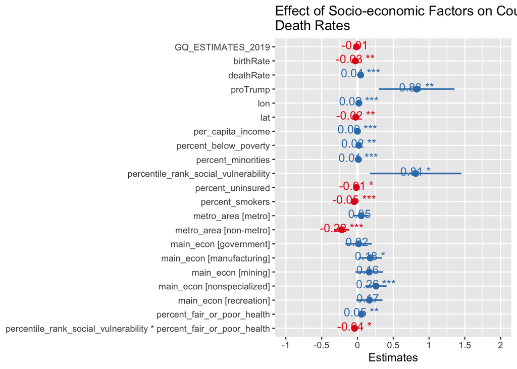

```r
#plot for fixed effects
#axis labels should be in order from bottom to top
#To see the values of the effect size and p-value, set show.values and show.p= TRUE.
#P-values will only be shown if the effect size values are too
sjPlot::plot_model(final.model, wrap.labels = 5,
                   #axis.labels=c("per capita income:percent minorities"...),
                   show.values=TRUE, show.p=TRUE,
                   title="Effect of Socio-economic Factors on County COVID Death Rates")
```

proTrump and percentile_rank_social_vulnerability

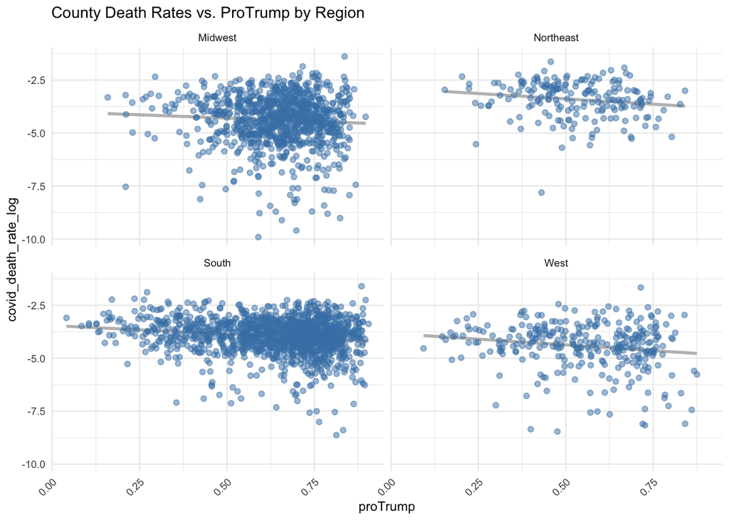

```r
ggplot(mydata, aes(x=proTrump, y = covid_death_rate_log)) +
   geom_smooth(se=FALSE, method="lm", color="grey") +
   geom_point(color="steelblue", alpha=0.5) +
   facet_wrap(~region) +
   theme_minimal(base_size = 9) +
   theme(axis.text.x = element_text(angle = 45, hjust = 1)) +
   labs(title = "County Death Rates vs. ProTrump by Region")
```

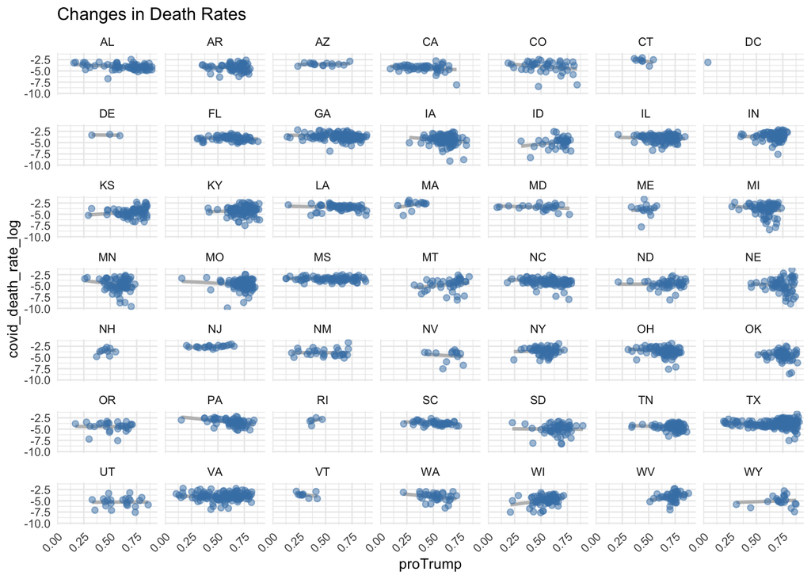

```r
ggplot(mydata, aes(x=proTrump, y = covid_death_rate_log)) +
   geom_smooth(se=FALSE, method="lm", color="grey") +
   geom_point(color="steelblue", alpha=0.5) +
   facet_wrap(~state) +
   theme_minimal(base_size = 9) +
   theme(axis.text.x = element_text(angle = 45, hjust = 1)) +
   labs(title = "Changes in Death Rates")
```

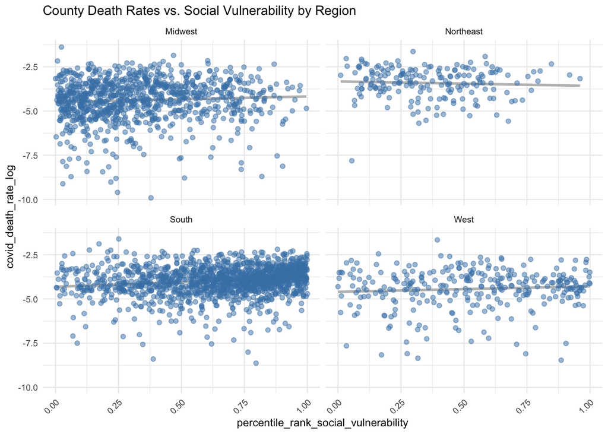

```r
ggplot(mydata, aes(x=percentile_rank_social_vulnerability, y = covid_death_rate_log)) +
   geom_smooth(se=FALSE, method="lm", color="grey") +
   geom_point(color="steelblue", alpha=0.5) +
   facet_wrap(~region) +
   theme_minimal(base_size = 9) +
   theme(axis.text.x = element_text(angle = 45, hjust = 1)) +
   labs(title = "County Death Rates vs. Social Vulnerability by Region")
```

# Model Diagnostics

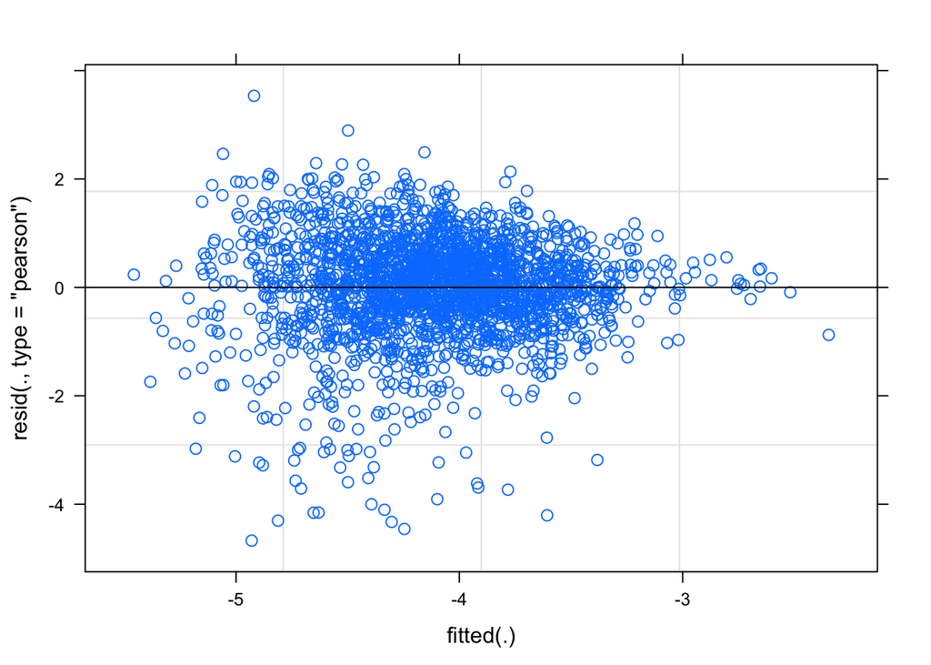

```r
plot(final.model, type=c("p", smooth))
```

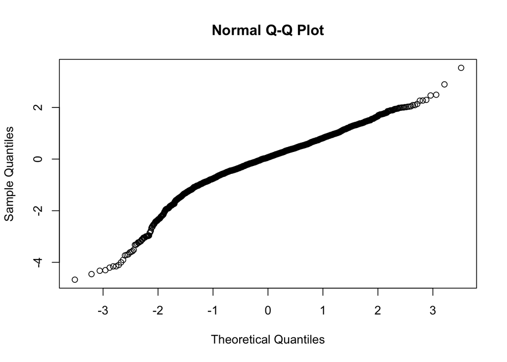

```r
qqnorm(residuals(final.model))
```

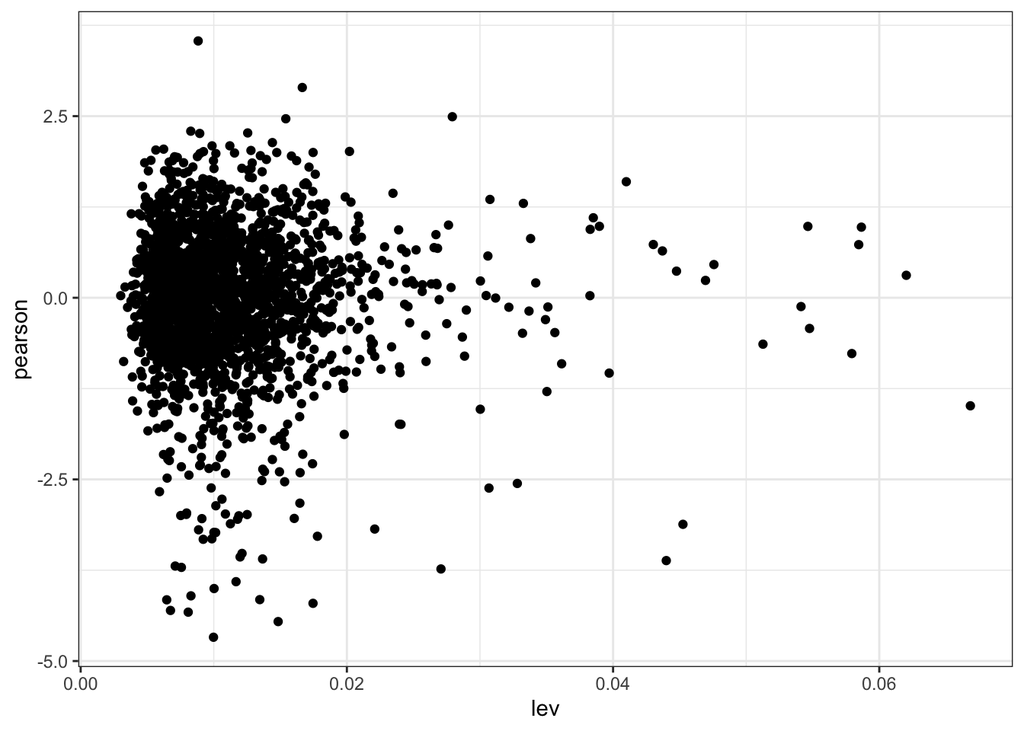

```r
ggplot(data.frame(lev=hatvalues(final.model),
       pearson=residuals(final.model, type="pearson")),
       aes(x=lev, y=pearson)) +
       geom_point() +
       theme_bw()
```

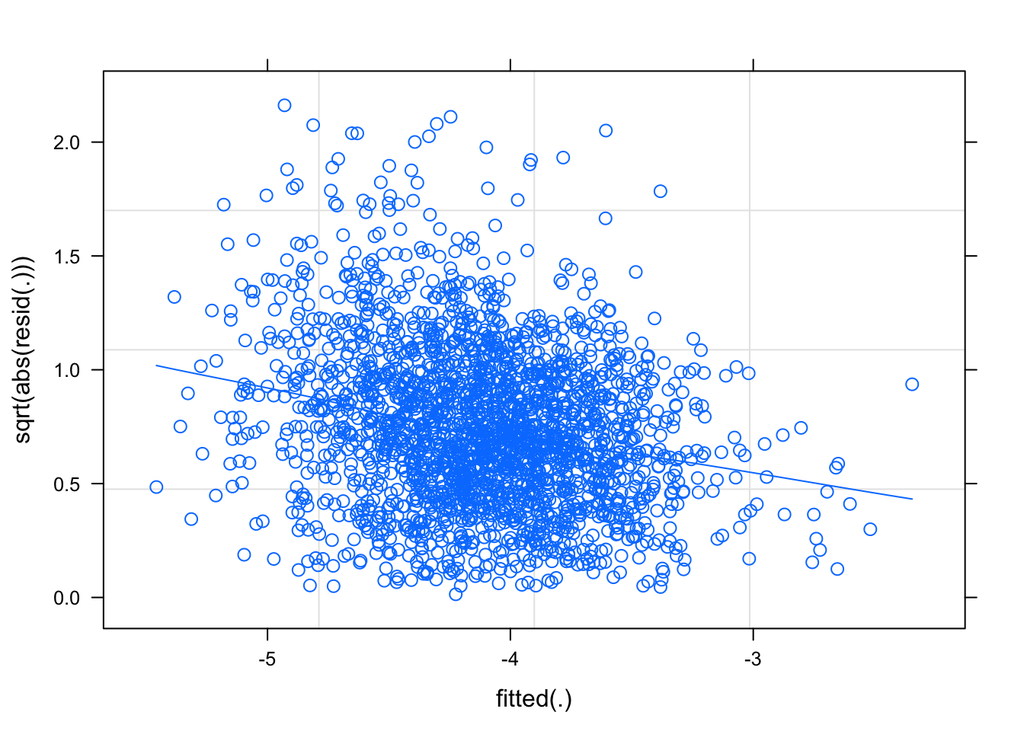

```r
# scale-location plots
plot(final.model, sqrt(abs(resid(.))) ~ fitted(.), type = c("p", "smooth"))
```

# CV

```r
#obtaining the mean-squared error for training set
pred.tr <- predict(final.model, train)
MSE.tr <- sum((pred.tr - train$covid_death_rate_log)^2)/nrow(train)
MSE.tr
```

```
## [1] 0.8584532
```

0.8584532

```r
#obtaining the mean-squared error for test set
pred.te <- predict(final.model, test)
MSE.te <- sum((pred.te - test$covid_death_rate_log)^2)/nrow(test)
MSE.te
```

```
## [1] 0.9024763
```

0.9024763

```r
#obtaining the mean-squared error for dataset
pred <- predict(final.model, mydata)
MSE <- sum((pred - mydata$covid_death_rate_log)^2)/nrow(mydata)
MSE
```

```
## [1] 0.8672671
```

0.8672671

```r
#https://cran.r-project.org/web/packages/groupdata2/vignettes/cross-validation_with_groupdata2.html
set.seed(1)
train <- fold(train, k = 10)
train <- train %>% arrange(.folds) # order by .folds
```

```r
crossvalidate <- function(data, k, model, dependent, random){
  # 'data' is the training set with the ".folds" column
  # 'k' is the number of folds we have
  # 'model' is a string describing a linear regression model formula
  # 'dependent' is a string with the name of the score column we want to predict
  # 'random' is a logical; do we have random effects in the model?

  # Initialize empty list for recording performances
  performances <- c()

  # One iteration per fold
  for (fold in 1:k){
    # Create training set for this iteration
    # Subset all the datapoints where .folds does not match the current fold
    training_set <- data[data$.folds != fold,]

    # Create test set for this iteration
    # Subset all the datapoints where .folds matches the current fold
    testing_set <- data[data$.folds == fold,]

    ## Train model
    # If there is a random effect,
    # use lmer() to train model
    # else use lm()
    if (isTRUE(random)){
      # Train linear mixed effects model on training set
      model <- lmer(model, training_set, REML=FALSE)
    } else {
      # Train linear model on training set
      model <- lm(model, training_set)
    }
    ## Test model
    # Predict the dependent variable in the testing_set with the trained model
    predicted <- predict(model, testing_set, allow.new.levels=TRUE)

    # Get the Root Mean Square Error between the predicted and the observed
    RMSE <- rmse(predicted, testing_set[[dependent]])

    # Add the RMSE to the performance list
    performances[fold] <- RMSE
  }
  # Return the mean of the recorded RMSEs
  #return(performances)
  #return(c('RMSE' = mean(performances)))
  return(mean(performances))
}
```

```r
set.seed(1)
RMSE.tr <- crossvalidate(train, k=10, final.model, dependent="covid_death_rate_log", random = TRUE)
MSE.tr <- RMSE.tr^2
MSE.tr
```

```
## [1] 0.8780328
```

MSE: 0.8780328

```r
# Creating the model for the full training set
cv.model <- lmer(final.model, train, REML = FALSE)
# Predict the dependent variable in the test_set with the trained model
predicted <- predict(cv.model, test, allow.new.levels=TRUE)

# Get the Root Mean Square Error between the predicted and the observed
RMSE.te <- rmse(predicted, test[["covid_death_rate_log"]])
```

```r
MSE.te <- RMSE.te^2
MSE.te
```

```
## [1] 0.9023038
```

MSE: 0.9023038

```r
# Summarize the results
summary(cv.model)
```

```
## Linear mixed model fit by maximum likelihood  ['lmerMod']
## Formula: covid_death_rate_log ~ GQ_ESTIMATES_2019 + birthRate + deathRate +
##     proTrump + lon + lat + per_capita_income + percent_below_poverty +
##     percent_minorities + percentile_rank_social_vulnerability +
##     percent_uninsured + percent_smokers + metro_area + main_econ +
##     percent_fair_or_poor_health + (1 | region) + percentile_rank_social_vulnerability *
##     percent_fair_or_poor_health
##    Data: train
##
##      AIC      BIC   logLik deviance df.resid
##   6146.8   6284.2  -3049.4   6098.8     2241
##
## Scaled residuals:
##     Min      1Q  Median      3Q     Max
## -5.0434 -0.4847  0.0727  0.5930  3.8134
##
## Random effects:
##  Groups   Name        Variance Std.Dev.
##  region   (Intercept) 0.0457   0.2138
##  Residual             0.8600   0.9273
## Number of obs: 2265, groups:  region, 4
##
## Fixed effects:
##                                                                    Estimate
## (Intercept)                                                      -3.489e+00
## GQ_ESTIMATES_2019                                                -1.286e-02
## birthRate                                                        -2.867e-02
## deathRate                                                         4.414e-02
## proTrump                                                          8.275e-01
## lon                                                               1.994e-02
## lat                                                              -2.328e-02
## per_capita_income                                                 3.464e-05
## percent_below_poverty                                             1.957e-02
## percent_minorities                                                1.320e-02
## percentile_rank_social_vulnerability                              8.163e-01
## percent_uninsured                                                -1.497e-02
## percent_smokers                                                  -4.575e-02
## metro_areametro                                                   5.275e-02
## metro_areanon-metro                                              -2.199e-01
## main_econgovernment                                               1.478e-02
```

[output cut: 37 more lines]

```
## per_capita_income                                                  5.428
## percent_below_poverty                                              2.710
## percent_minorities                                                 5.178
## percentile_rank_social_vulnerability                               2.514
## percent_uninsured                                                 -2.339
## percent_smokers                                                   -3.785
## metro_areametro                                                    0.990
## metro_areanon-metro                                               -4.114
## main_econgovernment                                                0.158
## main_econmanufacturing                                             2.145
## main_econmining                                                    1.677
## main_econnonspecialized                                            3.421
## main_econrecreation                                                1.815
## percent_fair_or_poor_health                                        3.066
## percentile_rank_social_vulnerability:percent_fair_or_poor_health  -2.200
```

```
##
## Correlation matrix not shown by default, as p = 22 > 12.
## Use print(x, correlation=TRUE)  or
##     vcov(x)        if you need it
```

```
## fit warnings:
## Some predictor variables are on very different scales: consider rescaling
```

covid_death_rate_log ~ GQ_ESTIMATES_2019 + birthRate + deathRate +  
proTrump + lon + lat + per_capita_income + percent_below_poverty +  
percent_minorities + percentile_rank_social_vulnerability +  
percent_uninsured + percent_smokers + metro_area + main_econ +  
percent_fair_or_poor_health + (1 | region) +  
percentile_rank_social_vulnerability * percent_fair_or_poor_health

```r
sjPlot::tab_model(cv.model, show.re.var= TRUE,
                  #pred.labels =c("(Intercept)", "per capita income:percent minorities"...),
                  dv.labels= "Effect of Socio-economic Factors on County COVID Death Rates")
```

|  | Effect of Socio-economic Factors on County COVID Death Rates |  |  |
| --- | --- | --- | --- |
| Predictors | Estimates | CI | p |
| (Intercept) | -3.49 | -4.83 – -2.15 | **<0.001** |
| GQ_ESTIMATES_2019 | -0.01 | -0.05 – 0.02 | 0.456 |
| birthRate | -0.03 | -0.05 – -0.01 | **0.009** |
| deathRate | 0.04 | 0.02 – 0.06 | **<0.001** |
| proTrump | 0.83 | 0.30 – 1.35 | **0.002** |
| lon | 0.02 | 0.01 – 0.03 | **<0.001** |
| lat | -0.02 | -0.04 – -0.01 | **0.005** |
| per_capita_income | 0.00 | 0.00 – 0.00 | **<0.001** |
| percent_below_poverty | 0.02 | 0.01 – 0.03 | **0.007** |
| percent_minorities | 0.01 | 0.01 – 0.02 | **<0.001** |
| percentile_rank_social_vulnerability | 0.82 | 0.18 – 1.45 | **0.012** |
| percent_uninsured | -0.01 | -0.03 – -0.00 | **0.019** |
| percent_smokers | -0.05 | -0.07 – -0.02 | **<0.001** |
| metro_area [metro] | 0.05 | -0.05 – 0.16 | 0.322 |
| metro_area [non-metro] | -0.22 | -0.32 – -0.12 | **<0.001** |
| main_econ [government] | 0.01 | -0.17 – 0.20 | 0.874 |
| main_econ [manufacturing] | 0.18 | 0.02 – 0.34 | **0.032** |
| main_econ [mining] | 0.16 | -0.03 – 0.36 | 0.094 |
| main_econ [nonspecialized] | 0.26 | 0.11 – 0.41 | **0.001** |
| main_econ [recreation] | 0.17 | -0.01 – 0.35 | 0.070 |
| percent_fair_or_poor_health | 0.06 | 0.02 – 0.09 | **0.002** |
| percentile_rank_social_vulnerability * percent_fair_or_poor_health | -0.04 | -0.08 – -0.00 | **0.028** |
| Random Effects |  |  |  |
| σ<sup>2</sup> | 0.86 |  |  |
| τ<sub>00</sub> <sub>region</sub> | 0.05 |  |  |
| ICC | 0.05 |  |  |
| N <sub>region</sub> | 4 |  |  |
| Observations | 2265 |  |  |
| Marginal R<sup>2</sup> / Conditional R<sup>2</sup> | 0.201 / 0.241 |  |  |

```r
# Predict the dependent variable in the full data with the trained model
predicted <- predict(cv.model, mydata, allow.new.levels=TRUE)

# Get the Root Mean Square Error between the predicted and the observed
RMSE <- rmse(predicted, mydata[["covid_death_rate_log"]])
```

```r
MSE <- RMSE^2
MSE
```

```
## [1] 0.8672894
```

MSE: 0.8672894

```r
# Summary
summary <- data.frame(
  #var = c("MSE"),
  method = c("Polynomial Model", "Hierarchical Model", "GAM"),
  MSE = c(0.8919, 0.9023, 0.8900)
)
summary
```

| method | MSE |
| --- | --- |
| Polynomial Model | 0.8919 |
| Hierarchical Model | 0.9023 |
| GAM | 0.8900 |